# Kỹ thuật lập trình Python

## Làm quen với Numpy

### Bài 1. Tính toán trên dãy số

#### 1. Tạo một dãy số a có N phần tử (N = 10)

```python
import numpy as np  # Khai báo thư viện numpy

print("1. Tạo một dãy số a có N phần tử (N = 10)")

N = 10
# Tạo dãy số a gồm 10 số nguyên ngẫu nhiên từ 0 đến 9
a = np.random.randint(0, 10, size=N)

print("Day so a: ", a)
```

```
1. Tạo một dãy số a có N phần tử (N = 10)
Day so a:  [3 7 1 9 9 5 2 6 3 2]
```

#### 2. Các thao tác trên dãy số a

(a) Bình phương các phần tử trong dãy số  
(b) Tìm số lượng các phần tử của dãy số  
(c) In ra giá trị lớn nhất, giá trị nhỏ nhất và giá trị trung bình  
(d) Tính phương sai của dãy số $\sigma^2 = \frac{\sum{\left(a_i - \mu\right)^2}}{N - 1}$ với $\mu = \frac{\sum{a_i}}{N}$ và độ lệch chuẩn $var = \sqrt{\sigma^2}$

```python
import numpy as np

# Giả sử a đã được tạo
# a = np.random.randint(0, 10, size=10)

print("2. Các thao tác tính toán đơn giản với dãy số a")

# a) Bình phương các phần tử
a2 = a ** 2

# b) Số lượng phần tử
na = a.size  # hoặc len(a)

# c) Giá trị lớn nhất, nhỏ nhất, trung bình
v_max = np.max(a)
v_min = np.min(a)
v_avg = np.mean(a)

# d) Phương sai và độ lệch chuẩn
v_sigma2 = np.var(a, ddof=1)  # ddof=1 để tính phương sai mẫu
v_var = np.sqrt(v_sigma2)

# In kết quả
print("a. Binh phuong a: ", a2)
print("\nb. Do dai a: ", na)
print(f'\nc. Gia tri lon nhat: [{v_max}], gia tri nho nhat: [{v_min}], gia tri trung binh [{v_avg:.2f}]')
print(f'\nd. Phuong sai: [{v_sigma2:.2f}] va do lech chuan: [{v_var:.2f}]')
```

```
2. Các thao tác tính toán đơn giản với dãy số a
a. Binh phuong a:  [ 9 49  1 81 81 25  4 36  9  4]

b. Do dai a:  10

c. Gia tri lon nhat: [9], gia tri nho nhat: [1], gia tri trung binh [4.70]

d. Phuong sai: [8.68] va do lech chuan: [2.95]
```

#### 3. Toán tử trên hai dãy số

(a) Tạo dãy số x có 10 phần tử từ 1 đến 10 (dùng hàm np.arange)  
(b) Liệt kê và đếm số lượng phần tử chẵn và lẻ có trong dãy a và x  
(c) Tính khoảng cách giữa các phần tử ở vị trí lẻ của mảng a và x với $s = \sqrt{\sum{\left(a_i - x_i\right)^2}}$ với $i$ lẻ  
(d) Tìm khoảng cách nhỏ nhất giữa tập a và x. Ví dụ: min({1, 3, 5}, {2, 10, 8}} = 1

```python
import numpy as np

print("3. Xử lý khác trên dãy số")

# a) Tạo dãy số x có 10 phần tử từ 1 đến 10
x = np.arange(1, 11)  # np.arange(start, stop) → stop không bao gồm, nên dùng 11

print(f'a. Day so x: {x}')

# b) Liệt kê và đếm số lượng phần tử chẵn và lẻ trong a và x
achan = a[a % 2 == 0]
ale = a[a % 2 != 0]
xchan = x[x % 2 == 0]
xle = x[x % 2 != 0]

print(f'b. So luong a: Chan = {len(achan)}, Le = {len(ale)}')
print(f'   So luong x: Chan = {len(xchan)}, Le = {len(xle)}')

# c) Tính khoảng cách giữa các phần tử ở vị trí lẻ của mảng a và x
# i lẻ → chỉ số 0,2,4,... vì Python index từ 0
ai_le = a[1::2]  # các vị trí lẻ: 1,3,5,... index
xi_le = x[1::2]
s = np.sqrt(np.sum((ai_le - xi_le)**2))
print(f'c. Khoang cach s = {s:.2f}')

# d) Tìm khoảng cách nhỏ nhất giữa tập a và x
# dùng broadcasting hoặc meshgrid để tìm tất cả khoảng cách
distances = np.abs(a.reshape(-1, 1) - x.reshape(1, -1))
min_distance = np.min(distances)
print(f'd. Khoang cach nho nhat giua tap a va x: {min_distance}')
```

```
3. Xử lý khác trên dãy số
a. Day so x: [ 1  2  3  4  5  6  7  8  9 10]
b. So luong a: Chan = 3, Le = 7
   So luong x: Chan = 5, Le = 5
c. Khoang cach s = 10.91
d. Khoang cach nho nhat giua tap a va x: 0
```

```python
# Lọc các phần tử chẵn trong a và x
a_la_chan = a[a % 2 == 0]  # các phần tử chẵn trong a
a_chan = list(a_la_chan)   # chuyển thành list nếu muốn
n_a_chan = len(a_chan)     # số lượng phần tử chẵn trong a

x_la_chan = x[x % 2 == 0]  # các phần tử chẵn trong x
x_chan = list(x_la_chan)   # chuyển thành list
n_x_chan = len(x_chan)     # số lượng phần tử chẵn trong x

# In ra kết quả
print( "b. Cac phan tu chan trong day a, b: ")
print(f"+ Day a: {a}")
print(f"  - Loc chan: {a_la_chan}")
print(f"  - Day chua phan tu chan trong a: {a_chan}, so luong {n_a_chan} phan tu.")
print(f"+ Day x: {x}")
print(f"  - Loc chan: {x_la_chan}")
print(f"  - Day chua phan tu chan trong a: {x_chan}, so luong {n_x_chan} phan tu.")
```

```
b. Cac phan tu chan trong day a, b:
+ Day a: [3 7 1 9 9 5 2 6 3 2]
  - Loc chan: [2 6 2]
  - Day chua phan tu chan trong a: [np.int64(2), np.int64(6), np.int64(2)], so luong 3 phan tu.
+ Day x: [ 1  2  3  4  5  6  7  8  9 10]
  - Loc chan: [ 2  4  6  8 10]
  - Day chua phan tu chan trong a: [np.int64(2), np.int64(4), np.int64(6), np.int64(8), np.int64(10)], so luong 5 phan tu.
```

```python
# Chọn các phần tử ở vị trí lẻ (index 1,3,5,...)
v_le = list(range(1, min(len(a), len(x)), 2))  # danh sách chỉ số lẻ
a_le = a[v_le]  # các phần tử của a ở vị trí lẻ
x_le = x[v_le]  # các phần tử của x ở vị trí lẻ

# Tính hiệu và khoảng cách Euclid
hieu_le = a_le - x_le
kc_le = np.sqrt(np.sum(hieu_le**2))

# In kết quả
print("c.Tính hiệu các phần tử ở vị trí lẻ của mảng a và x: ")
print(f"+ Vi tri le trong a va x: {v_le}")
print(f"+ Day so a: {a} va cac so o vi tri le: {a_le}")
print(f"+ Day so x: {x} va cac so o vi tri le: {x_le}")
print(f"+ Hieu cua a va x o vi tri le: {hieu_le}")
print(f"+ Khoang cach cac phan tu cua a va x o vi tri le: {kc_le: .2f}")
```

```
c.Tính hiệu các phần tử ở vị trí lẻ của mảng a và x:
+ Vi tri le trong a va x: [1, 3, 5, 7, 9]
+ Day so a: [3 7 1 9 9 5 2 6 3 2] va cac so o vi tri le: [7 9 5 6 2]
+ Day so x: [ 1  2  3  4  5  6  7  8  9 10] va cac so o vi tri le: [ 2  4  6  8 10]
+ Hieu cua a va x o vi tri le: [ 5  5 -1 -2 -8]
+ Khoang cach cac phan tu cua a va x o vi tri le:  10.91
```

```python
# Tính khoảng cách tất cả các cặp phần tử giữa a và x
distances = np.abs(a[:, np.newaxis] - x)  # a[:, np.newaxis] biến a thành cột

# Lấy khoảng cách nhỏ nhất
v_min = np.min(distances)

# In kết quả
print(f"+ Day a: {a}")
print(f"+ Day x: {x}")
print(f"+ Khoang cach nho nhat: {v_min}")
```

```
+ Day a: [3 7 1 9 9 5 2 6 3 2]
+ Day x: [ 1  2  3  4  5  6  7  8  9 10]
+ Khoang cach nho nhat: 0
```

#### 4. Sinh ngẫu nhiên dãy số

(a) Sinh ngẫu nhiên dãy số có 100 phần tử theo phân bố đều với giá trị trong đoạn [1, 10] và vẽ đồ thị tần số xuất hiện
(b) Sinh ngẫu nhiên N diem (x, y) với y là hàm phân phối chuẩn $N(\mu = 1, \sigma^2 = 1.0)$:
$$ y = f\left(x| \mu, \sigma\right) = \frac{1}{\sigma\sqrt{2\pi}}exp\left(-\frac{\left(x - \mu\right)^2}{2\sigma^2}\right) $$ nơi mà $x \in [\mu - 5\sigma, \mu + 5\sigma]$
(c) Sinh ngẫu nhiên dãy số có 100000 phần tử theo phân bố chuẩn $N(\mu = 1, \sigma^2 = 1.0)$ và vẽ đồ thị tần số xuất hiện

```
a. Sinh ngẫu nhiên theo phân bố đều
+ Gia tri: [ 1  2  3  4  5  6  7  8  9 10]
+ So lan xuat hien: [ 6 11 10 10 11 18  9 10  7  8]
+ Do thi ham so xuat hien
```

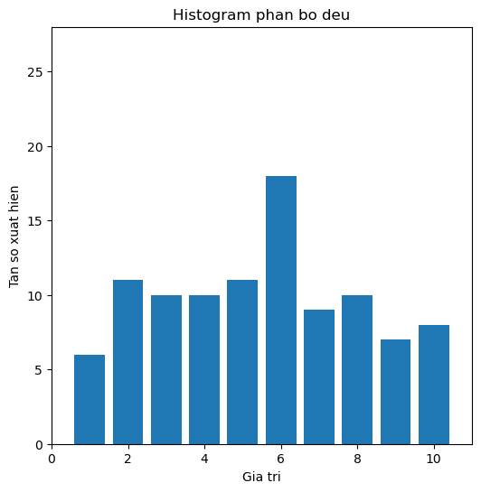

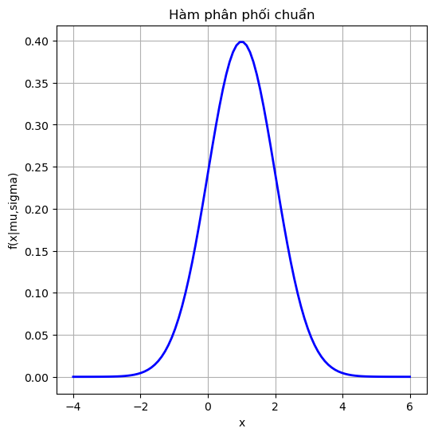

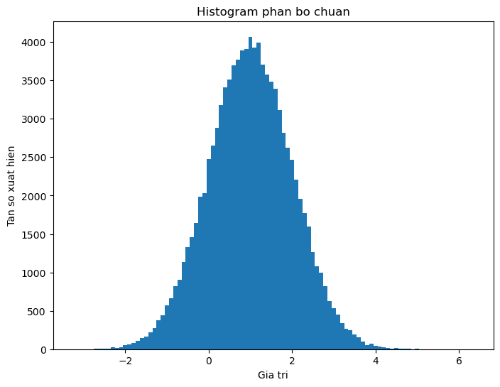

```python
import numpy as np
import matplotlib.pyplot as plt

# a) Sinh ngẫu nhiên 100 phần tử theo phân bố đều trong [1,10]
N = 100
a_random = np.random.randint(1, 11, size=N)  # randint: 1 đến 10
value, cnt = np.unique(a_random, return_counts=True)  # giá trị và tần số xuất hiện

print("a. Sinh ngẫu nhiên theo phân bố đều")
print(f"+ Gia tri: {value}")
print(f"+ So lan xuat hien: {cnt}")
print("+ Do thi ham so xuat hien")

plt.figure(figsize=(6,6))
plt.bar(value, cnt)
plt.xlim(0, 11)
plt.ylim(0, np.max(cnt)+10)
plt.xlabel("Gia tri")
plt.ylabel("Tan so xuat hien")
plt.title("Histogram phan bo deu")
plt.savefig("4a.png")
plt.show()


# b) Sinh N điểm (x, y) theo phân phối chuẩn
mu = 1
sigma = 1.0
N_points = 100

x = np.linspace(mu - 5*sigma, mu + 5*sigma, N_points)
y = (1/(sigma * np.sqrt(2*np.pi))) * np.exp(-((x - mu)**2)/(2*sigma**2))

plt.figure(figsize=(6,6))
plt.plot(x, y, 'b-', lw=2)
plt.xlabel("x")
plt.ylabel("f(x|mu,sigma)")
plt.title("Hàm phân phối chuẩn")
plt.grid(True)
plt.savefig("4b.png")
plt.show()


# c) Sinh ngẫu nhiên 100000 phần tử theo phân phối chuẩn
N_large = 100000
data = np.random.normal(mu, sigma, N_large)
value_c, cnt_c = np.unique(np.round(data, 1), return_counts=True)  # làm tròn để histogram

plt.figure(figsize=(8,6))
plt.bar(value_c, cnt_c, width=0.1)
plt.xlabel("Gia tri")
plt.ylabel("Tan so xuat hien")
plt.title("Histogram phan bo chuan")
plt.savefig("4c.png")
plt.show()
```

[output not shown]

[figure not shown]

```python
""" CÁC BẠN LÀM BÀI Ở ĐÂY """
# Sử dụm hàm np.random.rand() sinh số ngẫu nhiên trong [0,1) --> [0,1) * (b - a) + a --> [a, b)
# Sử dụng hàm sau để tính hàm xác suất chuẩn N(m, s): np.sqrt, np.exp
# ...

print("b. Sinh cặp (x, y) với y làm hàm phân phối chuẩn")
print(f"+ x: {x_min} <= min [{np.min(x): .2f}] <= max [{np.max(x): .2f}] <= {x_max}")
print(f"+ Ve ham so y(x)")
plt.figure(figsize=(6,6))      # kich thuoc ban ve
plt.scatter(x, y)              # ve cac diem (xi, yi)
plt.savefig("4b.png")          #  luu do thi
plt.show()                     #  hien thi do thi
```

[output not shown]

```
c. Sinh day so theo phan phoi chuan
+ x: len = 100000, min [-3.1407387869994956], max [5.121757546915363]
+ Mat so xac suat cua day so x
```

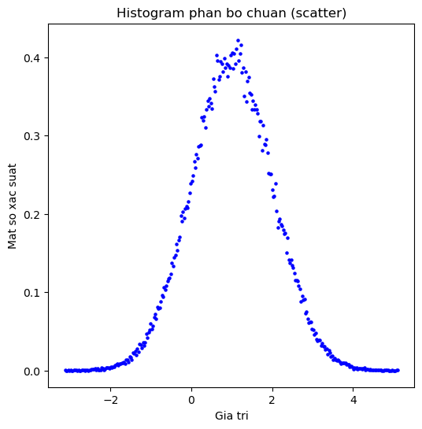

```python
import numpy as np
import matplotlib.pyplot as plt

# Sinh 100000 phần tử theo phân phối chuẩn N(mu=1, sigma^2=1)
mu = 1
sigma = 1.0
N_large = 100000

x = mu + sigma * np.random.randn(N_large)  # N(mu, sigma^2) = mu + sigma * N(0,1)

# Tính histogram dạng xác suất
cnt, val = np.histogram(x, bins=300, density=True)  # density=True để chuẩn hóa thành xác suất
val = (val[1:] + val[:-1]) / 2  # lấy trung điểm của mỗi bin

print("c. Sinh day so theo phan phoi chuan")
print(f"+ x: len = {len(x)}, min [{np.min(x)}], max [{np.max(x)}]")
print(f"+ Mat so xac suat cua day so x")

# Vẽ đồ thị scatter
plt.figure(figsize=(6,6))
plt.scatter(val, cnt, s=5, color='blue')
plt.xlabel("Gia tri")
plt.ylabel("Mat so xac suat")
plt.title("Histogram phan bo chuan (scatter)")
plt.show()
```

### Bài 2. Tính toán trên ma trận

#### 1. Tạo ma trận a có M = 6 dòng, N = 4 cột

```python
import numpy as np

# Tạo ma trận 6x4 với các giá trị ngẫu nhiên từ 100 đến 199
a = np.random.randint(100, 200, size=(6, 4))

print("Ma trận a: \n", a)
```

```
Ma trận a:
 [[180 103 119 108]
 [199 165 169 163]
 [128 198 181 199]
 [134 167 151 196]
 [120 121 108 183]
 [116 104 108 149]]
```

#### 2. Các thao tác trên ma trận a

(a) In ra ma trận chuyển vị  
(b) In ra phần tử ở vị trí dòng 2 cột 3  
(c) Trích xuất dòng đầu, dòng cuối, dòng 2  
(d) Trích xuất cột kế cuối, cột đầu  
(e) Đảo các giá trị trên từng cột  
(f) Tính tổng các dòng, trung bình các cột

```python
# a) Ma trận chuyển vị
a_t = a.T

# b) Phần tử ở dòng 2 cột 3 (index 1,2)
v_23 = a[1, 2]

# c) Trích xuất các dòng
d_0 = a[0, :]       # dòng đầu
d_last = a[-1, :]    # dòng cuối
d_2 = a[2, :]       # dòng thứ 3 (index 2)

# d) Trích xuất các cột
c_l1 = a[:, -2]      # cột kế cuối
c_0 = a[:, 0]        # cột đầu

# e) Đảo các giá trị trên từng cột
dao_cot = np.flipud(a)  # lật ngược theo trục dọc (cột giữ nguyên)

# f) Phép tính theo trục
tong_dong = np.sum(a, axis=1)    # tổng theo từng dòng
tb_cot = np.mean(a, axis=0)      # trung bình theo từng cột

# In kết quả
print(f"a. In ra ma trận chuyển vị: \n{a_t}")
print(f"\nb. In ra phần tử ở vị trí dòng 2 cột 3: {v_23}")
print(f"\nc. Trích xuất các dòng: ")
print(f"   + Dòng đầu : {d_0}")
print(f"   + Dòng cuối: {d_last}")
print(f"   + Dòng hai : {d_2}")
print(f"\nd. Trích xuất các cột: ")
print(f"   + Cột kế cuối: {c_l1}")
print(f"   + Cột đầu: {c_0}")
print(f"\ne. Đảo các giá trị trên từng cột: \n {dao_cot}")
print(f"\nf. Phép tính theo trục:")
print(f"   + Tổng dòng: {tong_dong}")
print(f"   + Trung bình cột: {tb_cot}")
```

```
a. In ra ma trận chuyển vị:
[[180 199 128 134 120 116]
 [103 165 198 167 121 104]
 [119 169 181 151 108 108]
 [108 163 199 196 183 149]]

b. In ra phần tử ở vị trí dòng 2 cột 3: 169

c. Trích xuất các dòng:
   + Dòng đầu : [180 103 119 108]
   + Dòng cuối: [116 104 108 149]
   + Dòng hai : [128 198 181 199]

d. Trích xuất các cột:
   + Cột kế cuối: [119 169 181 151 108 108]
   + Cột đầu: [180 199 128 134 120 116]

e. Đảo các giá trị trên từng cột:
 [[116 104 108 149]
 [120 121 108 183]
 [134 167 151 196]
 [128 198 181 199]
 [199 165 169 163]
 [180 103 119 108]]

f. Phép tính theo trục:
   + Tổng dòng: [510 696 706 648 532 477]
   + Trung bình cột: [146.16666667 143.         139.33333333 166.33333333]
```

#### 3. Các toán tử trên hai ma trận

(a) Tạo hai ma trận A và B có 4 dòng x 3 cột và X có 3 dòng x 4 cột  
(b) Tính tổng, hiệu, tích của từng phần tử trên hai ma trận A và B  
(c) Tính phép nhân ma trận Y = A x X

```python
import numpy as np

# a) Tạo ma trận
A = np.random.randint(1, 10, size=(4,3))
B = np.random.randint(1, 10, size=(4,3))
X = np.random.randint(1, 10, size=(3,4))

print("a. Tạo hai ma trận A và B có 4 dòng x 3 cột và X có 3 dòng x 4 cột")
print(f"+ Ma tran A: \n{A}")
print(f"+ Ma tran B: \n{B}")
print(f"+ Ma tran X: \n{X}")

# b) Tính tổng, hiệu, tích từng phần tử
AB_add = A + B
AB_sub = A - B
AB_mul = A * B   # tích từng phần tử (element-wise)

print("\nb. Tính tổng, hiệu, tích của từng phần tử trên hai ma trận A và B")
print(f"A + B = \n{AB_add}")
print(f"A - B = \n{AB_sub}")
print(f"A . B = \n{AB_mul}")

# c) Phép nhân ma trận Y = A x X
Y = np.dot(A, X)  # hoặc A @ X
print("\nc. Tính phép nhân ma trận Y = A x X")
print(f"Y = A x X --> shape A ({A.shape}) x shape X ({X.shape}) = shape Y ({Y.shape}) \n{Y}")
```

```
a. Tạo hai ma trận A và B có 4 dòng x 3 cột và X có 3 dòng x 4 cột
+ Ma tran A:
[[2 4 2]
 [4 3 7]
 [5 7 2]
 [5 1 6]]
+ Ma tran B:
[[7 6 2]
 [9 1 1]
 [4 7 5]
 [7 3 2]]
+ Ma tran X:
[[4 3 3 7]
 [6 9 4 9]
 [5 2 2 3]]

b. Tính tổng, hiệu, tích của từng phần tử trên hai ma trận A và B
A + B =
[[ 9 10  4]
 [13  4  8]
 [ 9 14  7]
 [12  4  8]]
A - B =
[[-5 -2  0]
 [-5  2  6]
 [ 1  0 -3]
 [-2 -2  4]]
A . B =
[[14 24  4]
 [36  3  7]
 [20 49 10]
 [35  3 12]]

c. Tính phép nhân ma trận Y = A x X
Y = A x X --> shape A ((4, 3)) x shape X ((3, 4)) = shape Y ((4, 4))
[[ 42  46  26  56]
 [ 69  53  38  76]
 [ 72  82  47 104]
 [ 56  36  31  62]]
```

#### 4. Giải hệ phương trình tuyến tính

```python
import numpy as np

# Giả sử A là ma trận 4x4 và y là vector 4 phần tử
A = np.random.randint(1, 10, size=(4,4))
y = np.random.randint(1, 10, size=(4,))

# Giải hệ Ax = y
x = np.linalg.solve(A, y)  # x = A^-1 y

# Kiểm tra nghiệm
yy = A @ x
diff = np.linalg.norm(yy - y)  # chuẩn 2 của vector yy - y

print(f"+ Ma tran A: \n{A}")
print(f"+ Vector y: {y}")
print(f"+ Nghiem x: {x}")
print(f"+ Kiem tra: yy = Ax = {yy} ==> ||yy -y ||_2 = {diff: .2f}")
```

```
+ Ma tran A:
[[6 2 6 7]
 [4 2 4 3]
 [7 2 1 3]
 [9 8 4 1]]
+ Vector y: [7 7 7 1]
+ Nghiem x: [ 3.375  -4.9375  3.375  -3.375 ]
+ Kiem tra: yy = Ax = [7. 7. 7. 1.] ==> ||yy -y ||_2 =  0.00
```

## Bài tập áp dụng

### Bài 3. Tính gần đúng số pi dùng phương pháp Monte Carlo

Vẽ một đường tròn $C$ có bán kính $r$ nội tiếp một hình vuông $C$, và đặt ngẫu nhiên $N$ chấm lên hình vuông. Tỉ lệ các chấm nằm trong hình tròn trên tổng số chấm xấp xỉ bằng diện tích của hình tròn chia cho hình vuông như sau: $$ \frac{N_C}{N} \approx \frac{\mathbb{S}_C}{\mathbb{S}_N} $$ nơi mà $N_C$ là các chấm trong hình tròn, $N$ là tổng số chấm, $\mathbb{S}_C$ và $\mathbb{S}_N$ lần lượt là diện tích của hình tròn và hình vuông. $$ \mathbb{S}_C = \pi * r^2 $$ $$ \mathbb{S}_N = (2*r)^2 = 4r^2 $$ Do đó, công thức trên trở thành: $$ \frac{N_C}{N} \approx \frac{\pi * r^2}{4r^2} = \frac{\pi}{4} $$ Suy ra, ta có giá trị số $\pi$ được tính như sau: $$ \pi \approx \frac{4N_C}{N} $$

Các bạn hãy lập trình tính sấp xỉ số $\pi$ dùng phương pháp Monte Carlo. Cho biết các sai số với $N = 100$, $N = 10000$, và $N = 1000000$. Vẽ đồ thị minh họa cho chương trình.

**Hướng dẫn**: Viết chương trình phát sinh $N$ điểm $(x_i, y_i)$ với $x_i, y_i \in [-1, -1]$. $(x_i, y_i)$ thuộc hình tròn tâm $(0, 0)$ bán kính 1 nội tiếp hình vuông có tâm tại $(0, 0)$ độ dài cạnh 2 khi và chỉ khi $x_i^2 + y_i^2 <= 1$.

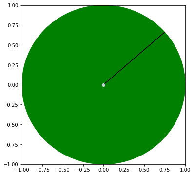

```python
import matplotlib.pyplot as plt # khai báo thư viện vẽ pyplot
import math

circle = plt.Circle((0, 0), 1, color='g') # tạo đối tượng vòng tròn

fig, ax = plt.subplots(figsize=(6, 6)) # lấy figure và vùng vẽ

plt.plot(0, 0, 'o', color=(0.9, 0.9, 1.0), alpha=0.8) # vẽ điểm tại tâm (0,0)
ax.add_patch(circle) # thêm vòng tròn vào vùng vẽ

x = 0.75; y = math.sqrt(1 - (x ** 2)) # (x = 0.75, y = căn bậc 2 của 1 - x^2)
plt.arrow(0, 0, x, y)

plt.xlim(-1, 1) # giới hạn trục x
plt.ylim(-1, 1) # giới hạn trục y

plt.savefig('pi.png') # lưu đồ thị xuống tập tin
plt.show()            # hiển thị đồ thị
```

```python
import numpy as np

def calc_pi_monte_carlo(n=100):
    # Sinh n điểm ngẫu nhiên trong hình vuông [0,1)x[0,1)
    x = np.random.rand(n)
    y = np.random.rand(n)

    # Kiểm tra xem điểm có nằm trong hình tròn bán kính 1 không
    inside_circle = (x**2 + y**2) <= 1

    # Tỷ lệ điểm nằm trong hình tròn nhân 4 sẽ xấp xỉ pi
    pi = 4 * np.sum(inside_circle) / n
    return pi
```

```python
import math

print("epsilon(n=100): ", calc_pi_monte_carlo(n = 100) - math.pi)
print("epsilon(n=100): ", calc_pi_monte_carlo(n = 100) - math.pi)
print("epsilon(n=10000): ", calc_pi_monte_carlo(n = 10000) - math.pi)
print("epsilon(n=10000): ", calc_pi_monte_carlo(n = 10000) - math.pi)
print("epsilon(n=1000000): ", calc_pi_monte_carlo(n = 1000000) - math.pi)
print("epsilon(n=1000000): ", calc_pi_monte_carlo(n = 1000000) - math.pi)
```

```
epsilon(n=100):  0.018407346410207026
epsilon(n=100):  0.21840734641020676
epsilon(n=10000):  -0.009592653589792999
epsilon(n=10000):  -0.017992653589792962
epsilon(n=1000000):  -0.0005366535897932678
epsilon(n=1000000):  -0.0019766535897929316
```